# Prueba Machine Learning : Ramon Yañez, Patricio Zapata

24-10-2020

### PREGUNTA 1 [0.75pt]

A veces, un algoritmo de machine learning no logra modelar bien los datos de entrenamiento ni generalizarse a nuevas observaciones. Elija la opción que mejor caracteriza a esta situación y justifique su elección.  
(a) Error de clasificación bajo.  
(b) Underfitting.  
(c) La varianza del error de estimación es pequeña.  
(d) Overfitting.

**Respuesta: (b) Underfitting**  
Justificación: Tenemos underfitting cuando los datos son pocos y no se puede generalizar el conocimiento.

### PREGUNTA 2 [0.75pt]

Hacer un árbol de decisión más profundo asegurará un mejor ajuste, pero probablemente reducirá la exactitud (accuracy) de la validación cruzada. Justifique. (a) Verdadero. (b) Falso

**Respuesta: Verdadero**  
Justificación: Al tener mas profundidad, el ajuste con la data de entrenamiento calza plenamente pero cuando queremos generalizar fallará asi mismo como hacer una predicción con otra data o validación cruzada

### PREGUNTA 3

**Creacion Data frame**

```r
mi_df <- data.frame(
  "Edad" = c("18-40", "18-40", "18-40", "18-40", "18-40", "18-40", "18-40", "41-60", "41-60" , "41-60" , "41-60" , "41-60" , "41-60" , "41-60" , ">60" , ">60", ">60", ">60", ">60", ">60", ">60" ),
  "Combo" = c("Fiesta", "Supremo", "Supremo", "Fiesta", "Supremo", "Mediano", "Supremo", "Mediano", "Mediano" , "Fiesta" , "Supremo" , "Fiesta" , "Supremo" , "Supremo" , "Fiesta" , "Mediano", "Mediano", "Fiesta", "Fiesta", "Supremo", "Supremo" )
)


glimpse(mi_df)
```

```
## Rows: 21
## Columns: 2
## $ Edad  <chr> "18-40", "18-40", "18-40", "18-40", "18-40", "18-40", "18-40", "…
## $ Combo <chr> "Fiesta", "Supremo", "Supremo", "Fiesta", "Supremo", "Mediano", …
```

```r
new <-  table(mi_df)
new
```

```
##        Combo
## Edad    Fiesta Mediano Supremo
##   >60        3       2       2
##   18-40      2       1       4
##   41-60      2       2       3
```

**(i) [0.25pt] Convierta el conjunto de datos en una tabla de frecuencia.**

```r
datos <- prop.table(new)
datos
```

```
##        Combo
## Edad        Fiesta    Mediano    Supremo
##   >60   0.14285714 0.09523810 0.09523810
##   18-40 0.09523810 0.04761905 0.19047619
##   41-60 0.09523810 0.09523810 0.14285714
```

**(ii) [0.25pt] Obtenga las probabilidades marginales por rango de Edad y Combo.**

```r
mayor_60 <-  sum(datos[1,])
mayor_60
```

```
## [1] 0.3333333
```

```r
entre_18_40  <-  sum(datos[2,])
entre_18_40
```

```
## [1] 0.3333333
```

```r
entre_41_60  <- sum(datos[3,])
entre_41_60
```

```
## [1] 0.3333333
```

```r
Fiesta  <- sum(datos[,1])
Fiesta
```

```
## [1] 0.3333333
```

```r
Mediano  <- sum(datos[,2])
Mediano
```

```
## [1] 0.2380952
```

```r
Supremo  <- sum(datos[,3])
Supremo
```

```
## [1] 0.4285714
```

**(iii) [1.00pt] Calcule la probabilidad de recomendar cada Combo dadoel rango de Edad, es decir, la probabilidad posterior de recomendación.**

```r
# p(fiesta | mayor a 60 )
#    A           B
# =
# ( p(mayor_60 | Fiesta) * P(fiesta) )  / P(mayor_60)
mayor_60_Fiesta <- datos[1,1]
(mayor_60_Fiesta * Fiesta) / mayor_60
```

```
## [1] 0.1428571
```

```r
# p(mediano | mayor a 60 )
#    A           B
# =
# ( p(mayor_60 | Mediano) * P(Mediano) )  / P(mayor_60)
mayor_60_Mediano <- datos[1,2]
(mayor_60_Mediano * Mediano) / mayor_60
```

```
## [1] 0.06802721
```

```r
# p(supremo | mayor a 60 )
#    A           B
# =
# ( p(mayor_60 | supremo) * P(supremo) )  / P(mayor_60)
mayor_60_Supremo <- datos[1,3]
(mayor_60_Supremo * Supremo) / mayor_60
```

```
## [1] 0.122449
```

```r
# p(fiesta | 18_40 )
#    A           B
# =
# ( p(18_40 | Fiesta) * P(fiesta) )  / P(18_40)
entre_18_40_Fiesta <- datos[2,1]
(entre_18_40_Fiesta * Fiesta) / entre_18_40
```

```
## [1] 0.0952381
```

```r
# p(mediano | 18_40 )
#    A           B
# =
# ( p(18_40 | mediano) * P(mediano) )  / P(18_40)
entre_18_40_mediano <- datos[2,2]
(entre_18_40_mediano * Mediano) / entre_18_40
```

```
## [1] 0.03401361
```

```r
# p(supremo | 18_40 )
#    A           B
# =
# ( p(18_40 | supremo) * P(supremo) )  / P(18_40)
entre_18_40_supremo <- datos[2,3]
(entre_18_40_supremo * Supremo) / entre_18_40
```

```
## [1] 0.244898
```

```r
# p(fiesta | 41_60 )
#    A           B
# =
# ( p(41_60 | Fiesta) * P(fiesta) )  / P(41_60)
entre_41_60_Fiesta <- datos[3,1]
(entre_41_60_Fiesta * Fiesta) / entre_41_60
```

```
## [1] 0.0952381
```

```r
# p(mediano | 41_60 )
#    A           B
# =
# ( p(41_60 | mediano) * P(mediano) )  / P(41_60)
entre_41_60_mediano <- datos[3,2]
(entre_41_60_mediano * Mediano) / entre_41_60
```

```
## [1] 0.06802721
```

```r
# p(supremo | 41_60 )
#    A           B
# =
# ( p(41_60 | supremo) * P(supremo) )  / P(41_60)
entre_41_60_supremo <- datos[3,3]
(entre_41_60_supremo * Supremo) / entre_41_60
```

```
## [1] 0.1836735
```

**(iv) [0.25pt] Si un cliente de 30 años (es decir, rango de edad: “18-40”) se conecta al sistema, ¿qué Combo recomendaría el algoritmo?**

Le recomendaría el combo supremo ya que nos da un 24% de probabilidad que lo consuma

### PREGUNTA 4

La base de datos wine (disponible en el paquete rattle.data) contiene información de 178 vinos. Se desea clasificar el tipo de vino (Type=1,2,3) a partir de 13 covariables disponibles. Aquí hay más detalles sobre cada variable. Cargue la base de datos y desarrolle los siguientes ítems:

**(i) [0.25pt] Estandarice las variables continuas.**

```r
data <- wine
glimpse(data)
```

```
## Rows: 178
## Columns: 14
## $ Type            <fct> 1, 1, 1, 1, 1, 1, 1, 1, 1, 1, 1, 1, 1, 1, 1, 1, 1, 1, …
## $ Alcohol         <dbl> 14.23, 13.20, 13.16, 14.37, 13.24, 14.20, 14.39, 14.06…
## $ Malic           <dbl> 1.71, 1.78, 2.36, 1.95, 2.59, 1.76, 1.87, 2.15, 1.64, …
## $ Ash             <dbl> 2.43, 2.14, 2.67, 2.50, 2.87, 2.45, 2.45, 2.61, 2.17, …
## $ Alcalinity      <dbl> 15.6, 11.2, 18.6, 16.8, 21.0, 15.2, 14.6, 17.6, 14.0, …
## $ Magnesium       <int> 127, 100, 101, 113, 118, 112, 96, 121, 97, 98, 105, 95…
## $ Phenols         <dbl> 2.80, 2.65, 2.80, 3.85, 2.80, 3.27, 2.50, 2.60, 2.80, …
## $ Flavanoids      <dbl> 3.06, 2.76, 3.24, 3.49, 2.69, 3.39, 2.52, 2.51, 2.98, …
## $ Nonflavanoids   <dbl> 0.28, 0.26, 0.30, 0.24, 0.39, 0.34, 0.30, 0.31, 0.29, …
## $ Proanthocyanins <dbl> 2.29, 1.28, 2.81, 2.18, 1.82, 1.97, 1.98, 1.25, 1.98, …
## $ Color           <dbl> 5.64, 4.38, 5.68, 7.80, 4.32, 6.75, 5.25, 5.05, 5.20, …
## $ Hue             <dbl> 1.04, 1.05, 1.03, 0.86, 1.04, 1.05, 1.02, 1.06, 1.08, …
## $ Dilution        <dbl> 3.92, 3.40, 3.17, 3.45, 2.93, 2.85, 3.58, 3.58, 2.85, …
## $ Proline         <int> 1065, 1050, 1185, 1480, 735, 1450, 1290, 1295, 1045, 1…
```

```r
summary(data)
```

```
##  Type      Alcohol          Malic            Ash          Alcalinity
##  1:59   Min.   :11.03   Min.   :0.740   Min.   :1.360   Min.   :10.60
##  2:71   1st Qu.:12.36   1st Qu.:1.603   1st Qu.:2.210   1st Qu.:17.20
##  3:48   Median :13.05   Median :1.865   Median :2.360   Median :19.50
##         Mean   :13.00   Mean   :2.336   Mean   :2.367   Mean   :19.49
##         3rd Qu.:13.68   3rd Qu.:3.083   3rd Qu.:2.558   3rd Qu.:21.50
##         Max.   :14.83   Max.   :5.800   Max.   :3.230   Max.   :30.00
##    Magnesium         Phenols        Flavanoids    Nonflavanoids
##  Min.   : 70.00   Min.   :0.980   Min.   :0.340   Min.   :0.1300
##  1st Qu.: 88.00   1st Qu.:1.742   1st Qu.:1.205   1st Qu.:0.2700
##  Median : 98.00   Median :2.355   Median :2.135   Median :0.3400
##  Mean   : 99.74   Mean   :2.295   Mean   :2.029   Mean   :0.3619
##  3rd Qu.:107.00   3rd Qu.:2.800   3rd Qu.:2.875   3rd Qu.:0.4375
##  Max.   :162.00   Max.   :3.880   Max.   :5.080   Max.   :0.6600
##  Proanthocyanins     Color             Hue            Dilution
##  Min.   :0.410   Min.   : 1.280   Min.   :0.4800   Min.   :1.270
##  1st Qu.:1.250   1st Qu.: 3.220   1st Qu.:0.7825   1st Qu.:1.938
##  Median :1.555   Median : 4.690   Median :0.9650   Median :2.780
##  Mean   :1.591   Mean   : 5.058   Mean   :0.9574   Mean   :2.612
##  3rd Qu.:1.950   3rd Qu.: 6.200   3rd Qu.:1.1200   3rd Qu.:3.170
##  Max.   :3.580   Max.   :13.000   Max.   :1.7100   Max.   :4.000
##     Proline
##  Min.   : 278.0
##  1st Qu.: 500.5
##  Median : 673.5
##  Mean   : 746.9
##  3rd Qu.: 985.0
##  Max.   :1680.0
```

```r
data[,-1] <- as.data.frame(scale(data[,-1]))
data[,-1]
```

```
##         Alcohol       Malic         Ash   Alcalinity   Magnesium      Phenols
## 1    1.51434077 -0.56066822  0.23139979 -1.166303174  1.90852151  0.806721729
## 2    0.24559683 -0.49800856 -0.82566722 -2.483840525  0.01809398  0.567048088
## 3    0.19632522  0.02117152  1.10621386 -0.267982252  0.08810981  0.806721729
## 4    1.68679140 -0.34583508  0.48655389 -0.806974805  0.92829983  2.484437221
## 5    0.29486844  0.22705328  1.83522559  0.450674485  1.27837900  0.806721729
## 6    1.47738706 -0.51591132  0.30430096 -1.286079296  0.85828399  1.557699140
## 7    1.71142720 -0.41744613  0.30430096 -1.465743481 -0.26196936  0.327374446
## 8    1.30493643 -0.16680747  0.88751034 -0.567422559  1.48842650  0.487156874
## 9    2.25341491 -0.62332789 -0.71631546 -1.645407665 -0.19195352  0.806721729
## 10   1.05857838 -0.88291793 -0.35180959 -1.046527051 -0.12193769  1.094330099
## 11   1.35420804 -0.15785609 -0.24245783 -0.447646437  0.36817315  1.046395371
## 12   1.37884384 -0.76654998 -0.16955666 -0.806974805 -0.33198519 -0.151972837
## 13   0.92308146 -0.54276546  0.15849862 -1.046527051 -0.75208020  0.487156874
## 14   2.15487169 -0.54276546  0.08559744 -2.423952463 -0.61204853  1.286069013
```

[output cut: 522 more lines]

**(ii) [0.25pt] Divida la base de datos en 70% para entrenamiento y 30% para prueba (Utilice una semilla para que el resultado sea replicable).**

```r
set.seed(2020)
posTraining <- sample(1:nrow(data), 0.7*nrow(data))
posTraining
```

```
##   [1] 156  87  22  65  17 164 170 109 128  56  42  80  29  98 131  66  93 120
##  [19] 132 114  78  76 158   7  18  52  44 123  82 138  95  70 111  43  32 124
##  [37]  88 141 171 163 148 167  77 129   3 166  25  69 107  58 102 139 160  35
##  [55]  24  50  33 118 155   8  85 169  13 165 173  68  19  23 113 150 168   1
##  [73]  47  86  31  60  16 147 142  55  26  10  90  28 175 174  40  15 152 151
##  [91] 136   5  48  20 153  14 116 149  41 103  92  27  59 125   2 119  61 144
## [109] 110  39  46  99  53  36 143 105 137  79 133  81  54  74  71 162
```

```r
data_training <- data[posTraining, ]
data_training
```

```
##     Type     Alcohol       Malic         Ash   Alcalinity   Magnesium
## 156    3  0.20864312  2.55441226 -0.16955666  0.750114792 -0.47201686
## 87     2 -1.03546501 -0.65018203 -0.20600725  0.989667037 -0.68206436
## 22     1 -0.08698653  1.31017034  1.03331269 -0.267982252  0.15812565
## 65     2 -1.02314711 -0.79340412  0.59590565 -0.148206130  0.29815732
## 17     1  1.60056608 -0.37268923  1.28846679  0.151234178  1.41841067
## 164    3 -0.05003283  0.99687202 -0.06020490 -0.297926283  0.43818899
## 170    3  0.49195487  2.02628080  1.79877500  1.648435713  0.85828399
## 109    2 -0.96155760 -0.93662621 -1.55467894 -0.148206130 -0.54203270
## 128    2 -1.49122740 -0.18471023  1.50717031  2.696476788 -0.54203270
## 56     1  0.68904131 -0.54276546  0.34075155  0.300954331  1.13834733
## 42     1  0.50427278  1.34597587 -0.89856839 -0.208094191 -0.68206436
## 80     2 -0.37029829  1.37283001  0.12204803  1.049555099  0.08810981
## 29     1  1.07089628 -0.39059199  1.58007149 -0.028430007  0.50820482
## 98     2 -0.87533228 -0.82920964 -1.40887660 -1.046527051 -1.03214354
```

[output cut: 360 more lines]

```r
data_test <- data[-posTraining, ]
data_test
```

```
##     Type     Alcohol       Malic         Ash   Alcalinity   Magnesium
## 4      1  1.68679140 -0.34583508  0.48655389 -0.806974805  0.92829983
## 6      1  1.47738706 -0.51591132  0.30430096 -1.286079296  0.85828399
## 9      1  2.25341491 -0.62332789 -0.71631546 -1.645407665 -0.19195352
## 11     1  1.35420804 -0.15785609 -0.24245783 -0.447646437  0.36817315
## 12     1  1.37884384 -0.76654998 -0.16955666 -0.806974805 -0.33198519
## 21     1  1.30493643 -0.63227927 -0.31535901 -1.046527051  1.83850567
## 30     1  1.25566482 -0.58752236 -0.57051311 -1.046527051 -0.26196936
## 34     1  0.93539936 -0.72179307  1.21556562  0.001514024  2.25860068
## 37     1  0.34414005 -0.62332789  1.72587383 -1.196247204  0.71825232
## 38     1  0.06082829 -0.61437650  0.66880683 -0.447646437 -0.12193769
## 45     1  0.06082829 -0.50695994 -0.97146956 -0.747086744  0.50820482
## 49     1  1.35420804 -0.28317542  0.12204803 -0.208094191  0.22814148
## 51     1  0.06082829 -0.54276546 -1.19017308 -2.124512156 -0.54203270
## 57     1  1.50202286 -0.56961960 -0.24245783 -0.956694959  1.27837900
```

[output cut: 150 more lines]

```r
nrow(data_training) + nrow(data_test) # Corroboramos 178 filas
```

```
## [1] 178
```

**(iii) [0.25pt] Implemente los algoritmos de Random Forest (20 árboles y 4 variables) y Support Vector Machine (kernel radial) utilizando todas las variables.**

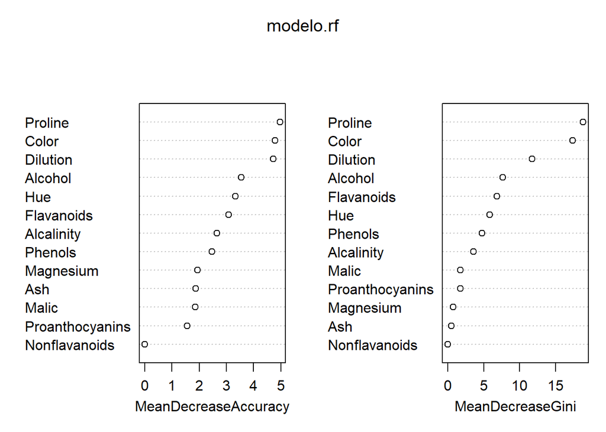

```r
#set.seed(2020)
# randomForest
modelo.rf <- randomForest(Type ~ ., data=data_training,
                         ntree=20, mtry=4, replace=TRUE, importance=T)

varImpPlot(modelo.rf)
```

```r
# set.seed(2020)
# SVM
modelo.svm <- svm(Type ~ ., data=data_training, kernel="radial")
modelo.svm
```

```
##
## Call:
## svm(formula = Type ~ ., data = data_training, kernel = "radial")
##
##
## Parameters:
##    SVM-Type:  C-classification
##  SVM-Kernel:  radial
##        cost:  1
##
## Number of Support Vectors:  58
```

**(iv) [0.25pt] ¿Cuál es el porcentaje de clasificaciones correctas para cada algoritmo utilizando la base de entrenamiento?**